# WVS: Happiness in Bolivia

## 2. Model diagnostics. Diagnostic plots’ description (plot(model))

1. Residuals Vs Fitted – red line is close to be horizontal, which indicates a close-to-linear relationship

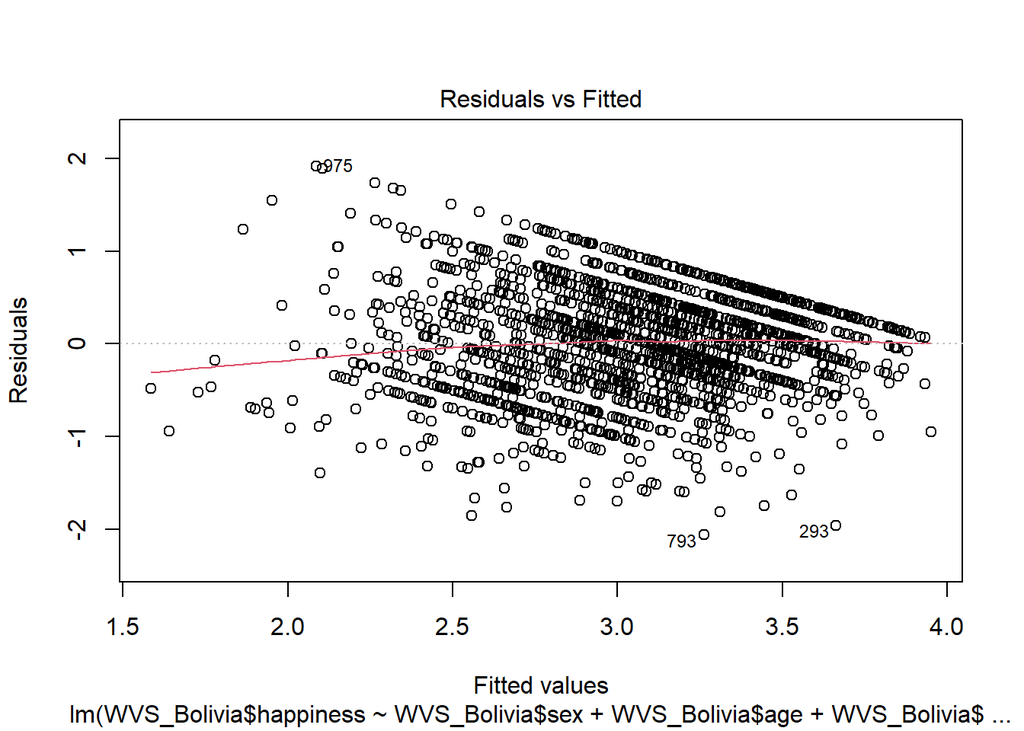

```r
plot(model_final, which = 1)
```

2. Normal QQ – it’s almost straight line, so the data is close to a normal distribution.

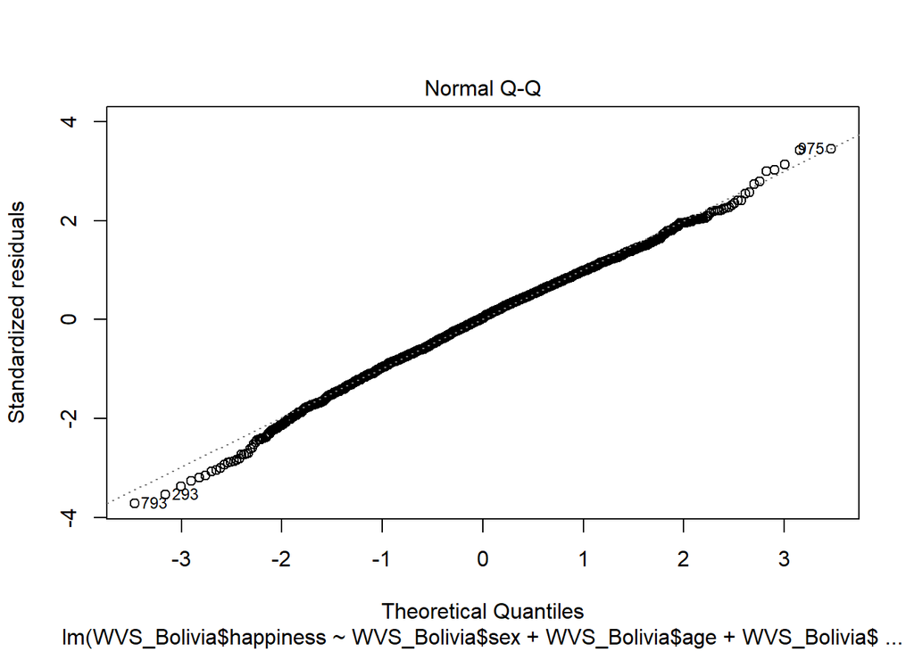

```r
plot(model_final, which = 2)
```

3. Scale-Location (Heteroscedasticity) – the residuals are not randomly located. Also, ncvTest is significant (p = < 2.22e-16), that is a sign of heteroscedasticity.

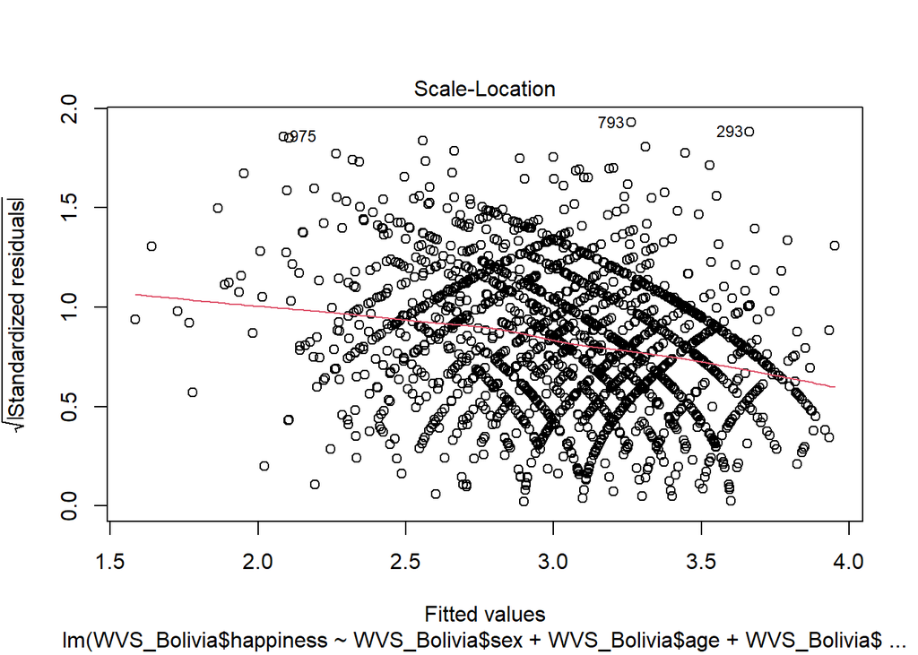

```r
plot(model_final, which = 3)
```

```r
ncvTest(model_final)
```

```
## Non-constant Variance Score Test
## Variance formula: ~ fitted.values
## Chisquare = 113.5902, Df = 1, p = < 2.22e-16
```

```r
outlierTest(model_final)
```

```
## No Studentized residuals with Bonferroni p < 0.05
## Largest |rstudent|:
##      rstudent unadjusted p-value Bonferroni p
## 793 -3.731268         0.00019619        0.371
```

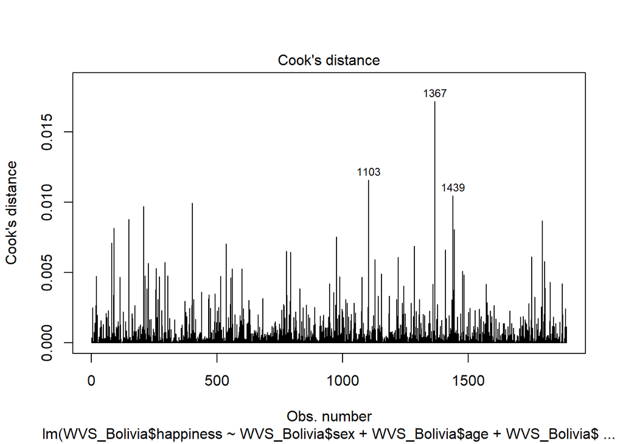

```r
plot(model_final, which = 4)
```

5. Multicollinearity test

Variance inflation factors are less than 5 for all predictors, therefore there is no multicollinearity in model_final.

```r
vif(model_final)
```

```
##                                     GVIF Df GVIF^(1/(2*Df))
## WVS_Bolivia$sex                 1.062203  1        1.030632
## WVS_Bolivia$age                 1.625073  1        1.274784
## WVS_Bolivia$income              1.169007  1        1.081206
## WVS_Bolivia$financial_status    1.221746  1        1.105326
## WVS_Bolivia$friends_imp         1.059100  3        1.009616
## WVS_Bolivia$family_trust        1.046769  1        1.023117
## WVS_Bolivia$family_status       1.609388  3        1.082539
## WVS_Bolivia$religion_VS_science 1.026976  1        1.013398
## WVS_Bolivia$health_status       1.151749  1        1.073196
## WVS_Bolivia$influence_on_life   1.115987  1        1.056403
```

## 3. Linearity check

To construct a non-linear relationship between variables factor of age as a predictor was taken. This model is statistically significant (p-value < 0.05). We can observe that the level of happiness among respondents aged 18 to 25 rises, then begins to gradually decrease until the age of 55, then slightly increases until the age of 70, and then drops quite sharply.

```r
library(gam)
model_non_linear_1 <- gam(WVS_Bolivia$happiness ~  s(WVS_Bolivia$age))
summary(model_non_linear_1)
```

```
##
## Call: gam(formula = WVS_Bolivia$happiness ~ s(WVS_Bolivia$age))
## Deviance Residuals:
##      Min       1Q   Median       3Q      Max
## -2.34584 -0.39390  0.06709  0.48098  1.28524
##
## (Dispersion Parameter for gaussian family taken to be 0.4379)
##
##     Null Deviance: 859.612 on 1890 degrees of freedom
## Residual Deviance: 825.8384 on 1886 degrees of freedom
## AIC: 3811.804
##
## Number of Local Scoring Iterations: NA
##
## Anova for Parametric Effects
##                      Df Sum Sq Mean Sq F value    Pr(>F)
## s(WVS_Bolivia$age)    1  27.81 27.8069  63.504 2.745e-15 ***
## Residuals          1886 825.84  0.4379
## ---
## Signif. codes:  0 '***' 0.001 '**' 0.01 '*' 0.05 '.' 0.1 ' ' 1
##
## Anova for Nonparametric Effects
##                    Npar Df Npar F    Pr(F)
## (Intercept)
## s(WVS_Bolivia$age)       3  4.542 0.003535 **
## ---
## Signif. codes:  0 '***' 0.001 '**' 0.01 '*' 0.05 '.' 0.1 ' ' 1
```

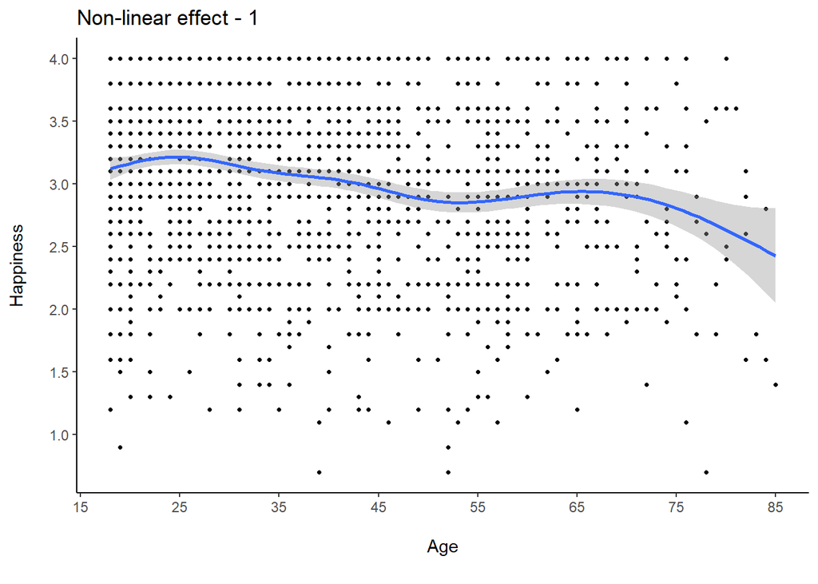

```r
ggplot(WVS_Bolivia, aes(age, happiness)) +
  geom_point(size = 0.9) +
  labs(x = "\nAge\n",
       y = "Happiness\n") +
  ggtitle("Non-linear effect - 1") +
  scale_x_continuous(breaks  = seq(15, 95, 10)) +
  scale_y_continuous(breaks  = seq(1, 4, 0.5)) +
  theme_classic()+
  stat_smooth(method = "gam", formula = y ~ s(x))
```

Another non-linear relationship was seen when taking influence on life as a predictor of happiness. This model is statistically significant (p-value < 0.05). It can be seen that for respondents who have little influence on their lives, the level of happiness is low and remains approximately the same in the range of 1-4 predictor units. Then, as the respondent’s influence on life increases, happiness also increases in the range from 4 to 8 units of the predictor. Then the level of happiness stabilizes and almost does not change in the range from 8 to 10 units of influence on life.

```r
library(gam)
model_non_linear_2 <- gam(WVS_Bolivia$happiness ~  s(WVS_Bolivia$influence_on_life))
summary(model_non_linear_2)
```

```
##
## Call: gam(formula = WVS_Bolivia$happiness ~ s(WVS_Bolivia$influence_on_life))
## Deviance Residuals:
##     Min      1Q  Median      3Q     Max
## -2.6163 -0.3726  0.0966  0.4837  1.4430
##
## (Dispersion Parameter for gaussian family taken to be 0.3974)
##
##     Null Deviance: 859.612 on 1890 degrees of freedom
## Residual Deviance: 749.5646 on 1886 degrees of freedom
## AIC: 3628.553
##
## Number of Local Scoring Iterations: NA
##
## Anova for Parametric Effects
##                                    Df Sum Sq Mean Sq F value    Pr(>F)
## s(WVS_Bolivia$influence_on_life)    1 101.65 101.647  255.76 < 2.2e-16 ***
## Residuals                        1886 749.56   0.397
## ---
## Signif. codes:  0 '***' 0.001 '**' 0.01 '*' 0.05 '.' 0.1 ' ' 1
##
## Anova for Nonparametric Effects
##                                  Npar Df Npar F     Pr(F)
## (Intercept)
## s(WVS_Bolivia$influence_on_life)       3 7.0456 0.0001041 ***
## ---
## Signif. codes:  0 '***' 0.001 '**' 0.01 '*' 0.05 '.' 0.1 ' ' 1
```

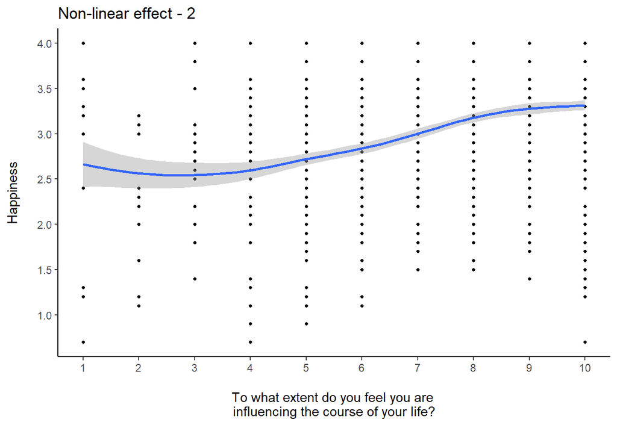

```r
ggplot(WVS_Bolivia, aes(influence_on_life, happiness)) +
  geom_point(size = 0.9) +
  labs(x = "\nTo what extent do you feel you are \ninfluencing the course of your life?\n",
       y = "Happiness\n") +
  ggtitle("Non-linear effect - 2") +
  scale_x_continuous(breaks  = seq(1, 10, 1)) +
  scale_y_continuous(breaks  = seq(1, 4, 0.5)) +
  theme_classic()+
  stat_smooth(method = "gam", formula = y ~ s(x))
```

## 4. Interaction effect

```r
model_interaction <- lm(happiness ~ age + sex + income + financial_status + friends_imp
                        + family_trust + religion_imp*family_status + religion_VS_science
                        + health_status + influence_on_life, WVS_Bolivia)
summary(model_interaction)
```

```
##
## Call:
## lm(formula = happiness ~ age + sex + income + financial_status +
##     friends_imp + family_trust + religion_imp * family_status +
##     religion_VS_science + health_status + influence_on_life,
##     data = WVS_Bolivia)
##
## Residuals:
##      Min       1Q   Median       3Q      Max
## -2.04931 -0.36112  0.02321  0.37968  1.92934
##
## Coefficients:
##                                               Estimate Std. Error t value
## (Intercept)                                   2.150951   0.102617  20.961
## age                                          -0.004037   0.001037  -3.891
## sex2                                         -0.021002   0.026549  -0.791
## income                                        0.017370   0.006856   2.534
## financial_status                              0.099918   0.006844  14.600
## friends_imp2                                 -0.047053   0.036945  -1.274
## friends_imp3                                 -0.075089   0.034124  -2.200
## friends_imp4                                 -0.104426   0.057706  -1.810
## family_trustTrust                             0.116940   0.034756   3.365
## religion_impImportant                        -0.067002   0.053841  -1.244
## family_statusSeparated                       -0.345015   0.152084  -2.269
## family_statusSingle                          -0.262682   0.069432  -3.783
## family_statusWindowed                        -0.416771   0.205417  -2.029
## religion_VS_scienceDisagree                  -0.069131   0.029037  -2.381
## health_statusNot so good                     -0.246749   0.027461  -8.985
## influence_on_life                             0.073064   0.006705  10.897
## religion_impImportant:family_statusSeparated  0.206171   0.161670   1.275
## religion_impImportant:family_statusSingle     0.195836   0.075067   2.609
## religion_impImportant:family_statusWindowed   0.332824   0.213123   1.562
##                                              Pr(>|t|)
## (Intercept)                                   < 2e-16 ***
## age                                          0.000103 ***
## sex2                                         0.429005
## income                                       0.011373 *
## financial_status                              < 2e-16 ***
## friends_imp2                                 0.202960
## friends_imp3                                 0.027895 *
## friends_imp4                                 0.070514 .
## family_trustTrust                            0.000782 ***
## religion_impImportant                        0.213491
## family_statusSeparated                       0.023407 *
## family_statusSingle                          0.000160 ***
## family_statusWindowed                        0.042609 *
## religion_VS_scienceDisagree                  0.017375 *
## health_statusNot so good                      < 2e-16 ***
## influence_on_life                             < 2e-16 ***
## religion_impImportant:family_statusSeparated 0.202376
## religion_impImportant:family_statusSingle    0.009158 **
## religion_impImportant:family_statusWindowed  0.118539
## ---
## Signif. codes:  0 '***' 0.001 '**' 0.01 '*' 0.05 '.' 0.1 ' ' 1
##
## Residual standard error: 0.5557 on 1872 degrees of freedom
## Multiple R-squared:  0.3275, Adjusted R-squared:  0.321
## F-statistic: 50.64 on 18 and 1872 DF,  p-value: < 2.2e-16
```

[figure not shown]

```r
plot_model(model_interaction, type = "pred",
           terms = c("religion_imp", "family_status"),
           title = "Predicted values of Happiness: \nInteraction effect - religion importance and family status",
           axis.title = c("Religion importance","Happiness"),
           dodge = 0.5) +
  theme_bw()+
  scale_x_discrete(limits = c("Not important", "Important"))+
  scale_colour_manual(name = "Family status",
                       values = c("#DB235E", "#24A300", "#AE7D66", "#007BA3"),
                       labels = c("Married", "Separated", "Widowed", "Single"))
```

# Meaningful interpretation

The conducted analysis allows both to accept a number of hypotheses, and to reject some of them or clarify them. Thus, despite the assumption, **income** and **financial situation** factors are statistically significant in determining the level of happiness in Bolivia. The higher the income and the better the financial condition, the higher the level of happiness.

However, as expected, **family trust**, **marital status**, **the importance of friendship**, **the importance of religion over science** are significant factors in determining happiness in Bolivia. Family, family trust, friendship allow the respondent to feel happier than the respondent for whom these factors are not important, or who has difficulties with marital status - divorce, widowhood. In addition, another important determinants of happiness were identified - the **state of health** of the respondent and their ability to **influence life**.

# Conclusion

To sum up, it cannot be argued that in Bolivia, as one of the poorest countries in Latin America, material factors as happiness predictors are insignificant. Those factors retain an influence on happiness, while the role of non-material factors - family, friends, health, and to a lesser extent - religion is also great. This may be due to the fact that material factors provide an opportunity to improve non-material factors, such as health or the quality of family provision.